# comparison example

Luran Manfio

7/22/2020

## we are going to review 3 major points of the Netflix data.

Data: https://www.kaggle.com/shivamb/netflix-shows

we are going to review the top 10 genres, directors, actors, and countries. these will be displayed in the form of figures below.

## Genre

we can see that from the 10 genres, the most populated is international. this is consistent with both movie and TV.

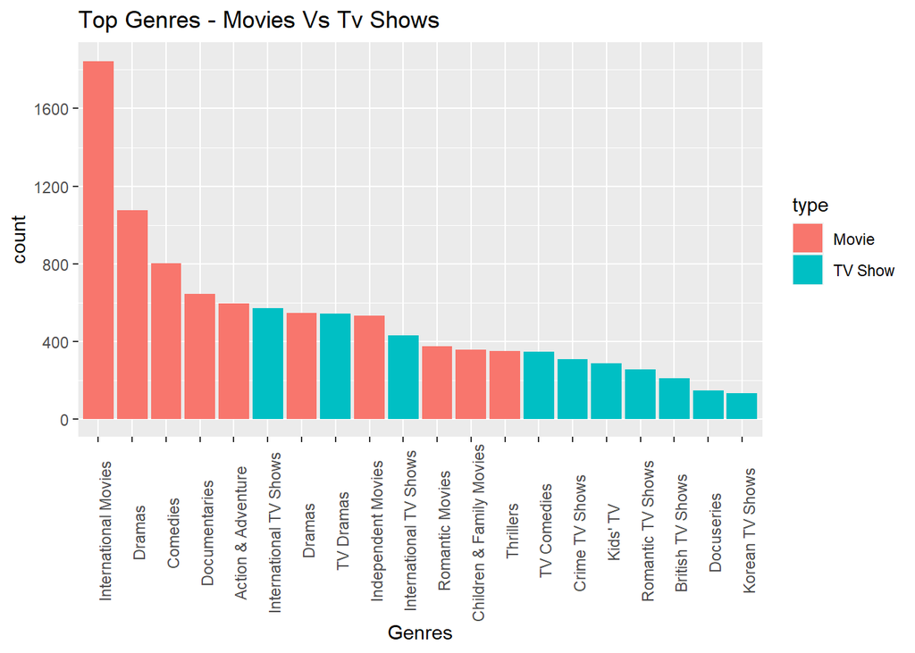

## Actors and Directors

here we can see that the top actors and directors in terms of how many films or shows they’ve been in/directed.

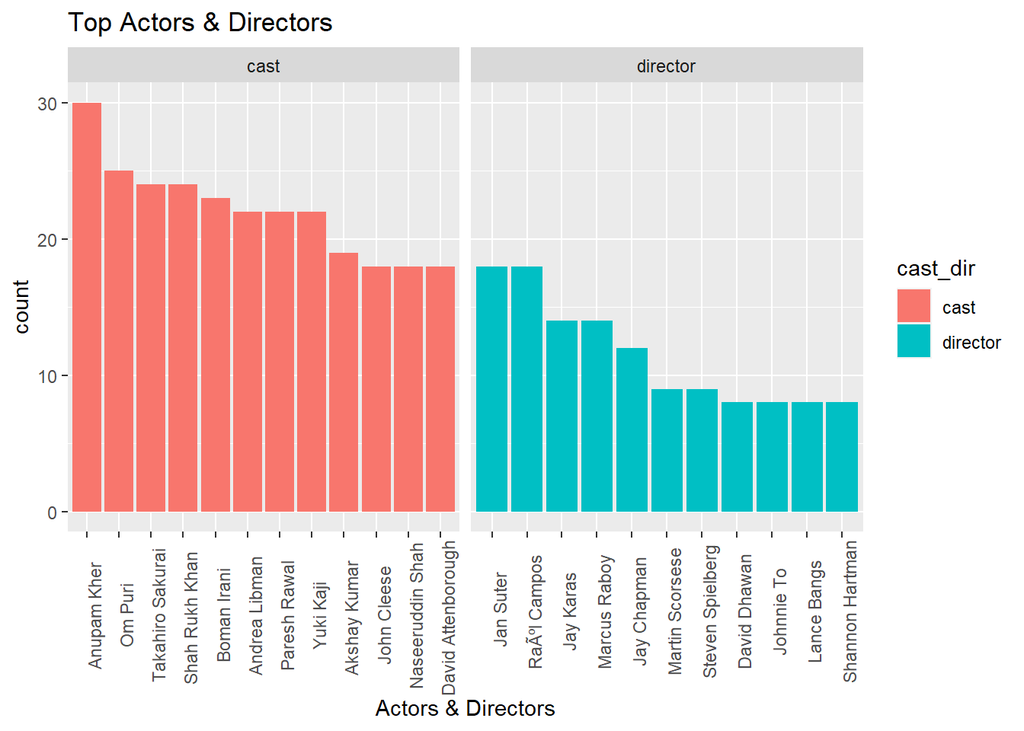

## Country

Here we can see what countries have the most films/shows are produced.

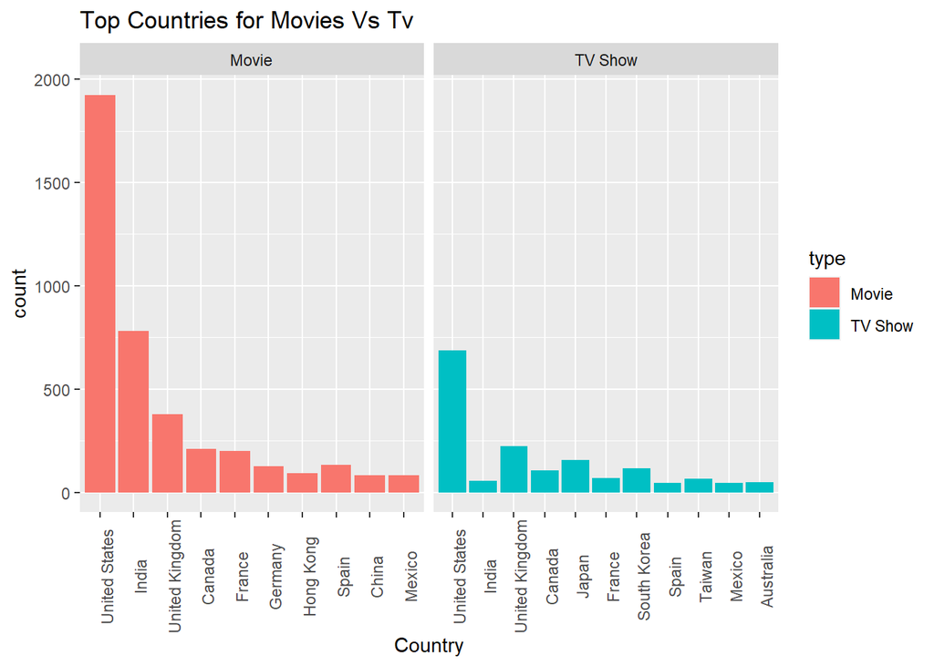

## Discussion:

We can compare the use of rmd to review data with shinyR. The example provided uses the same code to construct and organize the data as the ShinyR counterpart. The major difference in that we can not interact with the figures like in shiny. This is a major draw back for base markdown because this means all reports are static.

Now markdown does have it’s advantages, primarily that it works in chunks. When you review the raw code you can follow along and run each section independently to check if they’re working as intended. This makes markdown an effective method to start coding in R.